# **Prevenção de Ocorrência de Câncer de Mama**

Rodolfo R. Terra | Cientista de Dados

# **Sumário**

…

1. **Coletando os Dados**

2. **Pré-Processamento**

3. **Treinando o modelo com knn**

3.1. **Avaliando o Modelo 1 - knn**

3.2. **Interpretando os resultados do modelo 1 - knn**

3.3. **Otimizando a Performance - Modelo 2 - knn**

3.4. **Interpretando os resultados do modelo 2 - knn**

4. **Construindo um Modelo com Algoritmo Support Vector Machine (Ssvm) - modelo 3**

4.1. **Avaliando dos Modelo 3 (svm)**

4.2. **Interpretando os resultados do o Modelo 3 (svm)**

5. **Construindo o Modelo 4 - Random Forest**

5.1.**Interpretando os resultados do o Modelo 4 (Random Forest)**

6. **Conslusão**

## **Definição do Problema de Negócio**

##### Revisão de ocorrência de câncer de nama.

**Desenvolvimento de um modelo ML que que prever o tipo e câncer do paciente: Benigno ou maligno, analisando os exames médicos.**

##### O conjunto de dados foi pego no link abaixo, dados públicos para a utilização:

http://archive.ics.uci.edu/ml/datasets/Breast+Cancer+Wisconsin+%28Diagnostic%29

### **Etapa 1 - Coletando os Dados**

##### Aqui está a coleta de dados.

```r
# Coletando dados
dados <- read.csv("dataset.csv", stringsAsFactors = FALSE)
str(dados)
```

```
## 'data.frame':    569 obs. of  32 variables:
##  $ id               : int  87139402 8910251 905520 868871 9012568 906539 925291 87880 862989 89827 ...
##  $ diagnosis        : chr  "B" "B" "B" "B" ...
##  $ radius_mean      : num  12.3 10.6 11 11.3 15.2 ...
##  $ texture_mean     : num  12.4 18.9 16.8 13.4 13.2 ...
##  $ perimeter_mean   : num  78.8 69.3 70.9 73 97.7 ...
##  $ area_mean        : num  464 346 373 385 712 ...
##  $ smoothness_mean  : num  0.1028 0.0969 0.1077 0.1164 0.0796 ...
##  $ compactness_mean : num  0.0698 0.1147 0.078 0.1136 0.0693 ...
##  $ concavity_mean   : num  0.0399 0.0639 0.0305 0.0464 0.0339 ...
##  $ points_mean      : num  0.037 0.0264 0.0248 0.048 0.0266 ...
##  $ symmetry_mean    : num  0.196 0.192 0.171 0.177 0.172 ...
##  $ dimension_mean   : num  0.0595 0.0649 0.0634 0.0607 0.0554 ...
##  $ radius_se        : num  0.236 0.451 0.197 0.338 0.178 ...
##  $ texture_se       : num  0.666 1.197 1.387 1.343 0.412 ...
```

[output cut: 18 more lines]

```r
head(dados)
```

|  | id | diagnosis | radius_mean | texture_mean | perimeter_mean | area_mean | smoothness_mean | compactness_mean | concavity_mean | points_mean | symmetry_mean | dimension_mean | radius_se | texture_se | perimeter_se | area_se | smoothness_se | compactness_se | concavity_se | points_se | symmetry_se | dimension_se | radius_worst | texture_worst | perimeter_worst | area_worst | smoothness_worst | compactness_worst | concavity_worst | … |
| --- | --- | --- | --- | --- | --- | --- | --- | --- | --- | --- | --- | --- | --- | --- | --- | --- | --- | --- | --- | --- | --- | --- | --- | --- | --- | --- | --- | --- | --- | --- |
| 1 | 87139402 | B | 12.32 | 12.39 | 78.85 | 464.1 | 0.10280 | 0.06981 | 0.03987 | 0.03700 | 0.1959 | 0.05955 | 0.2360 | 0.6656 | 1.670 | 17.43 | 0.008045 | 0.011800 | 0.01683 | 0.012410 | 0.01924 | 0.002248 | 13.50 | 15.64 | 86.97 | 549.1 | 0.1385 | 0.1266 | 0.12420 | … |
| 2 | 8910251 | B | 10.60 | 18.95 | 69.28 | 346.4 | 0.09688 | 0.11470 | 0.06387 | 0.02642 | 0.1922 | 0.06491 | 0.4505 | 1.1970 | 3.430 | 27.10 | 0.007470 | 0.035810 | 0.03354 | 0.013650 | 0.03504 | 0.003318 | 11.88 | 22.94 | 78.28 | 424.8 | 0.1213 | 0.2515 | 0.19160 | … |
| 3 | 905520 | B | 11.04 | 16.83 | 70.92 | 373.2 | 0.10770 | 0.07804 | 0.03046 | 0.02480 | 0.1714 | 0.06340 | 0.1967 | 1.3870 | 1.342 | 13.54 | 0.005158 | 0.009355 | 0.01056 | 0.007483 | 0.01718 | 0.002198 | 12.41 | 26.44 | 79.93 | 471.4 | 0.1369 | 0.1482 | 0.10670 | … |
| 4 | 868871 | B | 11.28 | 13.39 | 73.00 | 384.8 | 0.11640 | 0.11360 | 0.04635 | 0.04796 | 0.1771 | 0.06072 | 0.3384 | 1.3430 | 1.851 | 26.33 | 0.011270 | 0.034980 | 0.02187 | 0.019650 | 0.01580 | 0.003442 | 11.92 | 15.77 | 76.53 | 434.0 | 0.1367 | 0.1822 | 0.08669 | … |
| 5 | 9012568 | B | 15.19 | 13.21 | 97.65 | 711.8 | 0.07963 | 0.06934 | 0.03393 | 0.02657 | 0.1721 | 0.05544 | 0.1783 | 0.4125 | 1.338 | 17.72 | 0.005012 | 0.014850 | 0.01551 | 0.009155 | 0.01647 | 0.001767 | 16.20 | 15.73 | 104.50 | 819.1 | 0.1126 | 0.1737 | 0.13620 | … |
| 6 | 906539 | B | 11.57 | 19.04 | 74.20 | 409.7 | 0.08546 | 0.07722 | 0.05485 | 0.01428 | 0.2031 | 0.06267 | 0.2864 | 1.4400 | 2.206 | 20.30 | 0.007278 | 0.020470 | 0.04447 | 0.008799 | 0.01868 | 0.003339 | 13.07 | 26.98 | 86.43 | 520.5 | 0.1249 | 0.1937 | 0.25600 | … |

```r
tail(dados)
```

|  | id | diagnosis | radius_mean | texture_mean | perimeter_mean | area_mean | smoothness_mean | compactness_mean | concavity_mean | points_mean | symmetry_mean | dimension_mean | radius_se | texture_se | perimeter_se | area_se | smoothness_se | compactness_se | concavity_se | points_se | symmetry_se | dimension_se | radius_worst | texture_worst | perimeter_worst | area_worst | smoothness_worst | compactness_worst | concavity_worst | … |
| --- | --- | --- | --- | --- | --- | --- | --- | --- | --- | --- | --- | --- | --- | --- | --- | --- | --- | --- | --- | --- | --- | --- | --- | --- | --- | --- | --- | --- | --- | --- |
| 564 | 894855 | B | 12.86 | 13.32 | 82.82 | 504.8 | 0.11340 | 0.08834 | 0.03800 | 0.03400 | 0.1543 | 0.06476 | 0.2212 | 1.0420 | 1.614 | 16.57 | 0.005910 | 0.02016 | 0.01902 | 0.010110 | 0.01202 | 0.003107 | 14.04 | 21.08 | 92.80 | 599.5 | 0.1547 | 0.2231 | 0.17910 | … |
| 565 | 911320502 | B | 13.17 | 18.22 | 84.28 | 537.3 | 0.07466 | 0.05994 | 0.04859 | 0.02870 | 0.1454 | 0.05549 | 0.2023 | 0.6850 | 1.236 | 16.89 | 0.005969 | 0.01493 | 0.01564 | 0.008463 | 0.01093 | 0.001672 | 14.90 | 23.89 | 95.10 | 687.6 | 0.1282 | 0.1965 | 0.18760 | … |
| 566 | 898677 | B | 10.26 | 14.71 | 66.20 | 321.6 | 0.09882 | 0.09159 | 0.03581 | 0.02037 | 0.1633 | 0.07005 | 0.3380 | 2.5090 | 2.394 | 19.33 | 0.017360 | 0.04671 | 0.02611 | 0.012960 | 0.03675 | 0.006758 | 10.88 | 19.48 | 70.89 | 357.1 | 0.1360 | 0.1636 | 0.07162 | … |
| 567 | 873885 | M | 15.28 | 22.41 | 98.92 | 710.6 | 0.09057 | 0.10520 | 0.05375 | 0.03263 | 0.1727 | 0.06317 | 0.2054 | 0.4956 | 1.344 | 19.53 | 0.003290 | 0.01395 | 0.01774 | 0.006009 | 0.01172 | 0.002575 | 17.80 | 28.03 | 113.80 | 973.1 | 0.1301 | 0.3299 | 0.36300 | … |
| 568 | 911201 | B | 14.53 | 13.98 | 93.86 | 644.2 | 0.10990 | 0.09242 | 0.06895 | 0.06495 | 0.1650 | 0.06121 | 0.3060 | 0.7213 | 2.143 | 25.70 | 0.006133 | 0.01251 | 0.01615 | 0.011360 | 0.02207 | 0.003563 | 15.80 | 16.93 | 103.10 | 749.9 | 0.1347 | 0.1478 | 0.13730 | … |
| 569 | 9012795 | M | 21.37 | 15.10 | 141.30 | 1386.0 | 0.10010 | 0.15150 | 0.19320 | 0.12550 | 0.1973 | 0.06183 | 0.3414 | 1.3090 | 2.407 | 39.06 | 0.004426 | 0.02675 | 0.03437 | 0.013430 | 0.01675 | 0.004367 | 22.69 | 21.84 | 152.10 | 1535.0 | 0.1192 | 0.2840 | 0.40240 | … |

### **Etapa 2 - Pré-Processamento**

##### Independentemente do método de aprendizagem de máquina, deve sempre ser excluídas variáveis de **“ID”**. Caso contrário, isso pode levar a resultados errados porque o **ID** pode ser usado para unicamente **“prever”** cada exemplo. Por conseguinte, um modelo que inclui um identificador pode sofrer de superajuste (overfitting), e será muito difícil usá-lo para generalizar outros dados.

```r
dados$id <- NULL

# Ajustando o label da variável alvo
dados$diagnosis = sapply(dados$diagnosis, function(x){ifelse(x=="M", "Maligno", "Benigno")})

head(dados)
```

|  | diagnosis | radius_mean | texture_mean | perimeter_mean | area_mean | smoothness_mean | compactness_mean | concavity_mean | points_mean | symmetry_mean | dimension_mean | radius_se | texture_se | perimeter_se | area_se | smoothness_se | compactness_se | concavity_se | points_se | symmetry_se | dimension_se | radius_worst | texture_worst | perimeter_worst | area_worst | smoothness_worst | compactness_worst | concavity_worst | points_worst | … |
| --- | --- | --- | --- | --- | --- | --- | --- | --- | --- | --- | --- | --- | --- | --- | --- | --- | --- | --- | --- | --- | --- | --- | --- | --- | --- | --- | --- | --- | --- | --- |
| 1 | Benigno | 12.32 | 12.39 | 78.85 | 464.1 | 0.10280 | 0.06981 | 0.03987 | 0.03700 | 0.1959 | 0.05955 | 0.2360 | 0.6656 | 1.670 | 17.43 | 0.008045 | 0.011800 | 0.01683 | 0.012410 | 0.01924 | 0.002248 | 13.50 | 15.64 | 86.97 | 549.1 | 0.1385 | 0.1266 | 0.12420 | 0.09391 | … |
| 2 | Benigno | 10.60 | 18.95 | 69.28 | 346.4 | 0.09688 | 0.11470 | 0.06387 | 0.02642 | 0.1922 | 0.06491 | 0.4505 | 1.1970 | 3.430 | 27.10 | 0.007470 | 0.035810 | 0.03354 | 0.013650 | 0.03504 | 0.003318 | 11.88 | 22.94 | 78.28 | 424.8 | 0.1213 | 0.2515 | 0.19160 | 0.07926 | … |
| 3 | Benigno | 11.04 | 16.83 | 70.92 | 373.2 | 0.10770 | 0.07804 | 0.03046 | 0.02480 | 0.1714 | 0.06340 | 0.1967 | 1.3870 | 1.342 | 13.54 | 0.005158 | 0.009355 | 0.01056 | 0.007483 | 0.01718 | 0.002198 | 12.41 | 26.44 | 79.93 | 471.4 | 0.1369 | 0.1482 | 0.10670 | 0.07431 | … |
| 4 | Benigno | 11.28 | 13.39 | 73.00 | 384.8 | 0.11640 | 0.11360 | 0.04635 | 0.04796 | 0.1771 | 0.06072 | 0.3384 | 1.3430 | 1.851 | 26.33 | 0.011270 | 0.034980 | 0.02187 | 0.019650 | 0.01580 | 0.003442 | 11.92 | 15.77 | 76.53 | 434.0 | 0.1367 | 0.1822 | 0.08669 | 0.08611 | … |
| 5 | Benigno | 15.19 | 13.21 | 97.65 | 711.8 | 0.07963 | 0.06934 | 0.03393 | 0.02657 | 0.1721 | 0.05544 | 0.1783 | 0.4125 | 1.338 | 17.72 | 0.005012 | 0.014850 | 0.01551 | 0.009155 | 0.01647 | 0.001767 | 16.20 | 15.73 | 104.50 | 819.1 | 0.1126 | 0.1737 | 0.13620 | 0.08178 | … |
| 6 | Benigno | 11.57 | 19.04 | 74.20 | 409.7 | 0.08546 | 0.07722 | 0.05485 | 0.01428 | 0.2031 | 0.06267 | 0.2864 | 1.4400 | 2.206 | 20.30 | 0.007278 | 0.020470 | 0.04447 | 0.008799 | 0.01868 | 0.003339 | 13.07 | 26.98 | 86.43 | 520.5 | 0.1249 | 0.1937 | 0.25600 | 0.06664 | … |

```r
# Muitos classificadores requerem que as variáveis sejam do tipo Fator
table(dados$diagnosis)
```

```
##
## Benigno Maligno
##     357     212
```

```r
dados$diagnosis <- factor(dados$diagnosis, levels = c('Benigno', "Maligno"), labels = c("Benigno", "Maligno"))
str(dados$diagnosis)
```

```
##  Factor w/ 2 levels "Benigno","Maligno": 1 1 1 1 1 1 1 2 1 1 ...
```

```r
# Verificando a proporção
round(prop.table(table(dados$diagnosis))*100, digits = 1)
```

```
##
## Benigno Maligno
##    62.7    37.3
```

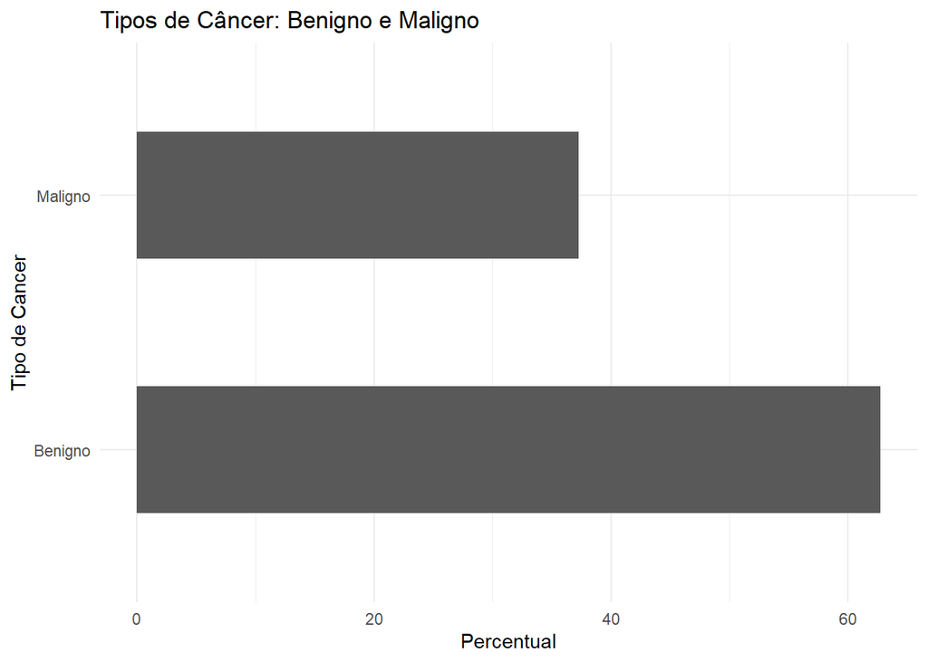

```r
library(ggplot2)

ggplot(dados, aes(x=diagnosis)) + ggtitle('Tipos de Câncer: Benigno e Maligno') + xlab("Tipo de Cancer") +
  geom_bar(aes(y = 100*(..count..)/sum(..count..)), width = 0.5) + ylab("Percentual") + coord_flip() + theme_minimal()
```

**Medida de Tendência Central**

Ao detectar um problema de escala entre os dados, é preciso realizar a normalização do modelo, ou seja, deixar todas as variáveis numéricas em uma mesma escala. O cálculo de distância feito pelo kNN é dependente das medidas de escala nos dados de entrada.

```r
summary(dados)
```

```
##    diagnosis    radius_mean      texture_mean   perimeter_mean
##  Benigno:357   Min.   : 6.981   Min.   : 9.71   Min.   : 43.79
##  Maligno:212   1st Qu.:11.700   1st Qu.:16.17   1st Qu.: 75.17
##                Median :13.370   Median :18.84   Median : 86.24
##                Mean   :14.127   Mean   :19.29   Mean   : 91.97
##                3rd Qu.:15.780   3rd Qu.:21.80   3rd Qu.:104.10
##                Max.   :28.110   Max.   :39.28   Max.   :188.50
##    area_mean      smoothness_mean   compactness_mean  concavity_mean
##  Min.   : 143.5   Min.   :0.05263   Min.   :0.01938   Min.   :0.00000
##  1st Qu.: 420.3   1st Qu.:0.08637   1st Qu.:0.06492   1st Qu.:0.02956
##  Median : 551.1   Median :0.09587   Median :0.09263   Median :0.06154
##  Mean   : 654.9   Mean   :0.09636   Mean   :0.10434   Mean   :0.08880
##  3rd Qu.: 782.7   3rd Qu.:0.10530   3rd Qu.:0.13040   3rd Qu.:0.13070
##  Max.   :2501.0   Max.   :0.16340   Max.   :0.34540   Max.   :0.42680
##   points_mean      symmetry_mean    dimension_mean      radius_se
##  Min.   :0.00000   Min.   :0.1060   Min.   :0.04996   Min.   :0.1115
##  1st Qu.:0.02031   1st Qu.:0.1619   1st Qu.:0.05770   1st Qu.:0.2324
##  Median :0.03350   Median :0.1792   Median :0.06154   Median :0.3242
##  Mean   :0.04892   Mean   :0.1812   Mean   :0.06280   Mean   :0.4052
##  3rd Qu.:0.07400   3rd Qu.:0.1957   3rd Qu.:0.06612   3rd Qu.:0.4789
##  Max.   :0.20120   Max.   :0.3040   Max.   :0.09744   Max.   :2.8730
##    texture_se      perimeter_se       area_se        smoothness_se
##  Min.   :0.3602   Min.   : 0.757   Min.   :  6.802   Min.   :0.001713
##  1st Qu.:0.8339   1st Qu.: 1.606   1st Qu.: 17.850   1st Qu.:0.005169
##  Median :1.1080   Median : 2.287   Median : 24.530   Median :0.006380
##  Mean   :1.2169   Mean   : 2.866   Mean   : 40.337   Mean   :0.007041
##  3rd Qu.:1.4740   3rd Qu.: 3.357   3rd Qu.: 45.190   3rd Qu.:0.008146
##  Max.   :4.8850   Max.   :21.980   Max.   :542.200   Max.   :0.031130
##  compactness_se      concavity_se       points_se         symmetry_se
##  Min.   :0.002252   Min.   :0.00000   Min.   :0.000000   Min.   :0.007882
##  1st Qu.:0.013080   1st Qu.:0.01509   1st Qu.:0.007638   1st Qu.:0.015160
##  Median :0.020450   Median :0.02589   Median :0.010930   Median :0.018730
##  Mean   :0.025478   Mean   :0.03189   Mean   :0.011796   Mean   :0.020542
##  3rd Qu.:0.032450   3rd Qu.:0.04205   3rd Qu.:0.014710   3rd Qu.:0.023480
##  Max.   :0.135400   Max.   :0.39600   Max.   :0.052790   Max.   :0.078950
##   dimension_se        radius_worst   texture_worst   perimeter_worst
##  Min.   :0.0008948   Min.   : 7.93   Min.   :12.02   Min.   : 50.41
##  1st Qu.:0.0022480   1st Qu.:13.01   1st Qu.:21.08   1st Qu.: 84.11
##  Median :0.0031870   Median :14.97   Median :25.41   Median : 97.66
##  Mean   :0.0037949   Mean   :16.27   Mean   :25.68   Mean   :107.26
##  3rd Qu.:0.0045580   3rd Qu.:18.79   3rd Qu.:29.72   3rd Qu.:125.40
##  Max.   :0.0298400   Max.   :36.04   Max.   :49.54   Max.   :251.20
##    area_worst     smoothness_worst  compactness_worst concavity_worst
##  Min.   : 185.2   Min.   :0.07117   Min.   :0.02729   Min.   :0.0000
##  1st Qu.: 515.3   1st Qu.:0.11660   1st Qu.:0.14720   1st Qu.:0.1145
##  Median : 686.5   Median :0.13130   Median :0.21190   Median :0.2267
##  Mean   : 880.6   Mean   :0.13237   Mean   :0.25427   Mean   :0.2722
##  3rd Qu.:1084.0   3rd Qu.:0.14600   3rd Qu.:0.33910   3rd Qu.:0.3829
##  Max.   :4254.0   Max.   :0.22260   Max.   :1.05800   Max.   :1.2520
##   points_worst     symmetry_worst   dimension_worst
##  Min.   :0.00000   Min.   :0.1565   Min.   :0.05504
##  1st Qu.:0.06493   1st Qu.:0.2504   1st Qu.:0.07146
##  Median :0.09993   Median :0.2822   Median :0.08004
##  Mean   :0.11461   Mean   :0.2901   Mean   :0.08395
##  3rd Qu.:0.16140   3rd Qu.:0.3179   3rd Qu.:0.09208
##  Max.   :0.29100   Max.   :0.6638   Max.   :0.20750
```

```r
summary(dados[c("radius_mean", "area_mean", "smoothness_mean")])
```

```
##   radius_mean       area_mean      smoothness_mean
##  Min.   : 6.981   Min.   : 143.5   Min.   :0.05263
##  1st Qu.:11.700   1st Qu.: 420.3   1st Qu.:0.08637
##  Median :13.370   Median : 551.1   Median :0.09587
##  Mean   :14.127   Mean   : 654.9   Mean   :0.09636
##  3rd Qu.:15.780   3rd Qu.: 782.7   3rd Qu.:0.10530
##  Max.   :28.110   Max.   :2501.0   Max.   :0.16340
```

**Criando uma Função de Normalização**

```r
normalizar <- function(x){
  return ((x - min(x)) / (max(x) - min(x)))
}
```

**Normalizando os Dados**

```r
dados_norm <- as.data.frame(lapply(dados[2:31], normalizar))
head(dados_norm)
```

|  | radius_mean | texture_mean | perimeter_mean | area_mean | smoothness_mean | compactness_mean | concavity_mean | points_mean | symmetry_mean | dimension_mean | radius_se | texture_se | perimeter_se | area_se | smoothness_se | compactness_se | concavity_se | points_se | symmetry_se | dimension_se | radius_worst | texture_worst | perimeter_worst | area_worst | smoothness_worst | compactness_worst | concavity_worst | points_worst | symmetry_worst | … |
| --- | --- | --- | --- | --- | --- | --- | --- | --- | --- | --- | --- | --- | --- | --- | --- | --- | --- | --- | --- | --- | --- | --- | --- | --- | --- | --- | --- | --- | --- | --- |
| 1 | 0.2526859 | 0.0906324 | 0.2422777 | 0.13599152 | 0.4529205 | 0.1546838 | 0.09341612 | 0.18389662 | 0.4540404 | 0.2019798 | 0.04508419 | 0.06749470 | 0.04301937 | 0.01985065 | 0.2152497 | 0.07170968 | 0.04250000 | 0.2350824 | 0.1598188 | 0.04675041 | 0.1981501 | 0.09648188 | 0.1820808 | 0.08943669 | 0.4446279 | 0.09635106 | 0.09920128 | 0.3227148 | 0.2487680 | … |
| 2 | 0.1712812 | 0.3124789 | 0.1761454 | 0.08606575 | 0.3994764 | 0.2923747 | 0.14964855 | 0.13131213 | 0.4353535 | 0.3148694 | 0.12275937 | 0.18493635 | 0.12594826 | 0.03791198 | 0.1957032 | 0.25203533 | 0.08469697 | 0.2585717 | 0.3821410 | 0.08371682 | 0.1405194 | 0.29104478 | 0.1388017 | 0.05888714 | 0.3310440 | 0.21752966 | 0.15303514 | 0.2723711 | 0.2710428 | … |
| 3 | 0.1921056 | 0.2407846 | 0.1874784 | 0.09743372 | 0.4971563 | 0.1799276 | 0.07136832 | 0.12326044 | 0.3303030 | 0.2830666 | 0.03085280 | 0.22692716 | 0.02756443 | 0.01258503 | 0.1171092 | 0.05334665 | 0.02666667 | 0.1417503 | 0.1308324 | 0.04502301 | 0.1593739 | 0.38432836 | 0.1470193 | 0.07034015 | 0.4340619 | 0.11730749 | 0.08522364 | 0.2553608 | 0.2824759 | … |
| 4 | 0.2034644 | 0.1244505 | 0.2018520 | 0.10235419 | 0.5756974 | 0.2890007 | 0.10859888 | 0.23836978 | 0.3590909 | 0.2266217 | 0.08216549 | 0.21720297 | 0.05154785 | 0.03647380 | 0.3248802 | 0.24580166 | 0.05522727 | 0.3722296 | 0.1114144 | 0.08800077 | 0.1419424 | 0.09994670 | 0.1300862 | 0.06114825 | 0.4327412 | 0.15029446 | 0.06924121 | 0.2959107 | 0.1058545 | … |
| 5 | 0.3885182 | 0.1183632 | 0.3721927 | 0.24106045 | 0.2437483 | 0.1532421 | 0.07949859 | 0.13205765 | 0.3338384 | 0.1154170 | 0.02418975 | 0.01155852 | 0.02737596 | 0.02039231 | 0.1121460 | 0.09461652 | 0.03916667 | 0.1734230 | 0.1208420 | 0.03013280 | 0.2942014 | 0.09888060 | 0.2693859 | 0.15579532 | 0.2735918 | 0.14204771 | 0.10878594 | 0.2810309 | 0.1817465 | … |
| 6 | 0.2171896 | 0.3155225 | 0.2101444 | 0.11291622 | 0.2963799 | 0.1774124 | 0.12851453 | 0.07097416 | 0.4904040 | 0.2676917 | 0.06333514 | 0.23864038 | 0.06827498 | 0.02521115 | 0.1891763 | 0.13682519 | 0.11229798 | 0.1666793 | 0.1519390 | 0.08444233 | 0.1828531 | 0.39872068 | 0.1793914 | 0.08240759 | 0.3548174 | 0.16145181 | 0.20447284 | 0.2290034 | 0.2897694 | … |

### **Etapa 3 - Treinando o modelo com knn**

```r
library(class)
library(caTools)

# Criando dados de treino e dados de teste

dados_treino <- dados_norm[1:469, ]
dados_teste <- dados_norm[470:569, ]

# Criando os labels para os dados de treino e de teste
dados_treino_labels <- dados[1:469, 1]
dados_teste_labels <- dados[470:569, 1]
length(dados_treino_labels)
```

```
## [1] 469
```

```r
length(dados_teste_labels)
```

```
## [1] 100
```

```r
# Criando o modelo
modelo_knn_v1 <- knn(train = dados_treino,
                     test = dados_teste,
                     cl = dados_treino_labels,
                     k = 21)

# A função knn() retorna um objeto do tipo fator com as previsões para cada exemplo no dataset de teste

summary(modelo_knn_v1)
```

```
## Benigno Maligno
##      63      37
```

### **Etapa 3.1 - Avaliando o Modelo 1 - knn**

```r
library(gmodels)

# Criando uma tabela cruzada dos dados previstos x dados atuais
# Usaremos amostra com 100 observações: length(dados_teste_labels)
CrossTable(x = dados_teste_labels, y = modelo_knn_v1, prop.chisq = FALSE)
```

```
##
##
##    Cell Contents
## |-------------------------|
## |                       N |
## |           N / Row Total |
## |           N / Col Total |
## |         N / Table Total |
## |-------------------------|
##
##
## Total Observations in Table:  100
##
##
##                    | modelo_knn_v1
## dados_teste_labels |   Benigno |   Maligno | Row Total |
## -------------------|-----------|-----------|-----------|
##            Benigno |        61 |         0 |        61 |
##                    |     1.000 |     0.000 |     0.610 |
##                    |     0.968 |     0.000 |           |
##                    |     0.610 |     0.000 |           |
## -------------------|-----------|-----------|-----------|
##            Maligno |         2 |        37 |        39 |
##                    |     0.051 |     0.949 |     0.390 |
##                    |     0.032 |     1.000 |           |
##                    |     0.020 |     0.370 |           |
## -------------------|-----------|-----------|-----------|
##       Column Total |        63 |        37 |       100 |
##                    |     0.630 |     0.370 |           |
## -------------------|-----------|-----------|-----------|
##
##
```